# Supplement: More on Lists and Arrays

```python
import numpy as np
```

You can access elements of a list or array using negative indices.

The last element corresponds to -1, the second-to-last element corresponds to -2, etc.

```python
favorite_movies = ["Rear Window", "Inception", "Dead Poet Society", "Baby Driver", "Evil Dead (2013 remake)"]

print(favorite_movies[0]) # first element
print(favorite_movies[1]) # second element
print(favorite_movies[2]) # third element
print()
print(favorite_movies[-1]) # last element
print(favorite_movies[-2]) # second-to-last element
print(favorite_movies[-3]) # third-to-last element
```

```
Rear Window
Inception
Dead Poet Society

Evil Dead (2013 remake)
Baby Driver
Dead Poet Society
```

```python
z = np.array([5, 4, 37, 92, 209])

print(z[-1]) # last element
print(z[-2]) # 2nd to last element
```

```
209
92
```

You can add new elements to a list using the `.append` method.

```python
my_list = [7, 5, "Emory", -7, "Atlanta"]

print(my_list)

# add new item to the end of the list using the "append" method.
my_list.append("Department of Data and Decision Sciences")
print(my_list)
```

```
[7, 5, 'Emory', -7, 'Atlanta']
[7, 5, 'Emory', -7, 'Atlanta', 'Department of Data and Decision Sciences']
```

You can start with an empty list, then append new elements.

```python
my_list = [] # empty list
print(my_list)

my_list.append(1)
print(my_list)

my_list.append("abcd")
print(my_list)

my_list.append(33)
print(my_list)
```

```
[]
[1]
[1, 'abcd']
[1, 'abcd', 33]
```

Sorting lists with the `.sort` method

```python
# create lists
numerical_list = [5.3, 25, -0.1, -5, 11, 3, 1.2]
string_list = ["Frank", "Zev", "Peter", "Abigail", "Ali", "Eleanor"]

# sort them
numerical_list.sort()
string_list.sort()

# print out sorted versions
print(numerical_list)
print(string_list)
```

```
[-5, -0.1, 1.2, 3, 5.3, 11, 25]
['Abigail', 'Ali', 'Eleanor', 'Frank', 'Peter', 'Zev']
```

**Copying lists**

Remember that the assignment operator doesn't make a copy if you put a list on the left-hand side:

```python
list_of_floats = [2.3, -1.0, 5.1, 9.9]

not_a_copy = list_of_floats

list_of_floats[0] = "Nothing"

print(not_a_copy)
```

```
['Nothing', -1.0, 5.1, 9.9]
```

If you want to make a copy, use the `.copy` method

```python
list_of_floats = [2.3, -1.0, 5.1, 9.9]

copy_of_list = list_of_floats.copy()

list_of_floats[0] = "Nothing"

print(copy_of_list)
```

```
[2.3, -1.0, 5.1, 9.9]
```

**Other list methods**

See [here](https://docs.python.org/3/tutorial/datastructures.html) for all available list methods. Here are two more useful ones:

```python
# reverse the order of a list
colors = ["blue", "green", "red", "orange", "pink", "purple"]

colors.reverse()

print(colors)
```

```
['purple', 'pink', 'orange', 'red', 'green', 'blue']
```

```python
# count the number of times an item appears in the list
fav_colors = ["blue", "pink", "black", "pink", "red", "blue", "green", "black", "pink"]

pink_count = fav_colors.count("pink")

print(pink_count) # prints "3", the number of times "pink" appears in the list
```

```
3
```

## Numpy Arrays

Careful when making a copy...

```python
x = np.array([1.2, 2.4, 4.8, 9.6])

not_a_copy = x

copy_of_x = np.copy(x) # use numpy.copy function

x[0] = -24

print(not_a_copy)
print(copy_of_x)
```

```
[-24.    2.4   4.8   9.6]
[1.2 2.4 4.8 9.6]
```

**Append a single value**

```python
z = np.array([5.1, 3.0, -2, 4.4])
z = np.append(z, 12)
print(z)
```

```
[ 5.1  3.  -2.   4.4 12. ]
```

**Append multiple values**

```python
z = np.array([5.1, 3.0, -2, 4.4])
z = np.append(z, [13.1, 0.0, -1.0, 2.0])
print(z)
```

```
[ 5.1  3.  -2.   4.4 13.1  0.  -1.   2. ]
```

**Sorting arrays**

Sort the original array

```python
z = np.array([5.1, 3.0, -2, 4.4])

# sort the array z
z.sort()

print(z)
```

```
[-2.   3.   4.4  5.1]
```

Make a sorted copy

```python
z = np.array([5.1, 3.0, -2, 4.4])

# created a sorted copy of z. The original array is left unchanged
z_sorted = np.sort(z)

print(z_sorted)
print(z)
```

```
[-2.   3.   4.4  5.1]
[ 5.1  3.  -2.   4.4]
```

**Computing summary statistics of a NumPy array**

Method 1:

```python
c_vec = np.array([4.2, 1.2, 11.45, -2, 0, 9, 3.3, 2*np.pi])


print(np.mean(c_vec)) # mean
print(np.std(c_vec)) # standard deviation
print(np.median(c_vec)) # median
print(np.max(c_vec)) # maximum
print(np.min(c_vec)) # minimum
```

```
4.179148163397448
4.269494739300707
3.75
11.45
-2.0
```

Method 2:

```python
c_vec = np.array([4.2, 1.2, 11.45, -2, 0, 9, 3.3, 2*np.pi])

print(c_vec.mean())
print(c_vec.std())

# arrays don't have a .median() method for some reason...

print(c_vec.max())
print(c_vec.min())
```

```
4.179148163397448
4.269494739300707
11.45
-2.0
```

## Numpy Arrays of Random Numbers

Samples of random variables can be generated using the `numpy.random` sub-library

```python
import numpy as np

# Generate a single sample from a standard Normal Distribution
# "Standard Normal" means the mean is zero, and the standard deviation is one.

normal_sample = np.random.normal()
print(normal_sample)
```

```
-0.03991716418608664
```

```python
# Generate 10 samples from a standard Normal Distribution (saved in a numpy.array)

normal_sample = np.random.normal(size = 10)
print(normal_sample)
print(type(normal_sample))
```

```
[ 0.86289196  1.04963198  1.57944198 -0.48239111  0.03683652  0.93615371
 -0.52033191 -1.37141795  0.89789869 -0.88116181]
<class 'numpy.ndarray'>
```

```python
# To change the mean of the normal distribution, use the "loc" argument
# This refers to the *location* of the mean.

# generate single sample of normal distribution with mean = 1
single_sample = np.random.normal(loc = 1)

# generate 7 samples from a normal distribution with mean = 1
seven_samples = np.random.normal(loc = 1, size = 7)
print(single_sample)
print(seven_samples)
```

```
2.5885912905017987
[1.21966098 1.63007358 1.85009049 1.82080683 0.92517254 1.7752114
 0.58698947]
```

```python
# To change the standard deviation of the normal distribution, use the "scale" argument

# generate single sample of normal distribution with standard deviation = 2.4
single_sample = np.random.normal(scale = 2.4)

# generate 6 samples from a normal distribution with standard deviation = 2.4
six_samples = np.random.normal(scale = 2.4, size = 6)

# generate single sample from a normal distribution with standard deviation = 2.4, and mean = -1
single_sample_2 = np.random.normal(loc = -1, scale = 2.4)

# generate 5 samples from a normal distribution with standard deviation = 2.4, and mean = -1
five_samples = np.random.normal(loc = -1, scale = 2.4, size = 5)

print(single_sample)
print(six_samples)
print(single_sample_2)
print(five_samples)
```

```
-0.024776339203292155
[-3.62880223 -0.99602869  2.91324808  3.77620221  0.29918301 -0.80101416]
-1.0788992174448855
[-3.59612751 -1.53787068 -1.91458142  4.93381615 -2.92142396]
```

##### **Run the next cell 3 times in a row.** Notice that the random numbers change each time

```python
# run this 3 times
print(np.random.normal(loc = 0.5, scale = 3, size = 4))
```

```
[-4.33017225  4.81631432 -0.8867527  -3.6470577 ]
```

##### In order to reproduce results, we often want the same set of random numbers to be generated.

##### We can do this by drawing from a "pre-generated" set, which is called a **seed**

##### **Run the next cell 3 times in a row.** Notice that the numbers stay the same

```python
# run this cell 3 times, numbers will always be the same
np.random.seed(0)
print(np.random.normal(loc = 0.5, scale = 3, size = 4))
```

```
[5.79215704 1.70047163 3.43621395 7.2226796 ]
```

##### **Run the next cell 3 times in a row.** Notice that the numbers stay the same, but they are different than the previous cell

```python
# Choose a different seed by selecting a different non-negative integer in the seed function

# run this 3 times
np.random.seed(3497) # you can change to different integer like 1, 2, 3, 100, 431, 981423 etc.
print(np.random.normal(loc = 0.5, scale = 3, size = 4))
```

```
[-2.35967024 -2.15818152 -3.05627174  6.4943452 ]
```

#### Once we generate random variables from a distribution, we can create a **histogram**. This is a visual representation of the data, showing the frequency within ranges (known as bins)

#### Below, we generate a histogram of 1,000 samples of a standard normal variable using `matplotlib.pyplot`.

#### We set the seed so that the code is reproducible, i.e., the same values are drawn every time.

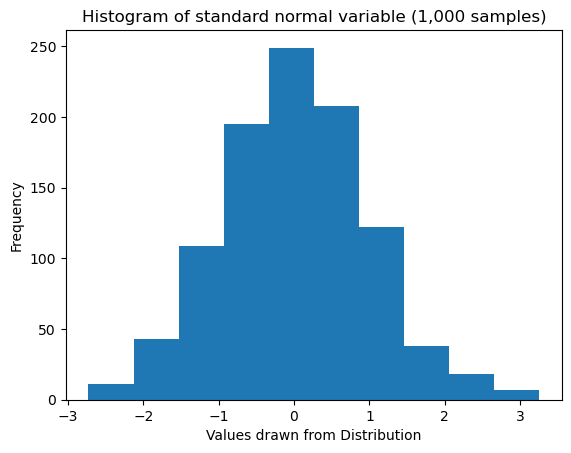

```python
import matplotlib.pyplot as plt

np.random.seed(1989)


sample_size = 1000

standard_normal_samples = np.random.normal(size = sample_size)

plt.hist(x = standard_normal_samples)
plt.xlabel("Values drawn from Distribution")
plt.ylabel("Frequency")
plt.title("Histogram of standard normal variable (1,000 samples)")
plt.show()
```